# SNP calling pipeline based on GATK

Apollo Lizano; Le Qin Choo

2025-03-19

This SNP calling pipeline was originally developed by Marvin and is described in the publication Choquet et al., 2019. However, Le Qin, Isabel, and I have made significant improvements, especially in terms of speed and automation. The pipeline processes your filtered .fastq.gz files and generates a final SNP-called output file with the extension .g.vcf.

This afternoon, we will go through the pipeline step by step.

## 1. Concatenate R1 and R2.fastq.gz file

```bash
ls *_1.fastq.gz > milkfish_individuals
sed -e s/_1.fastq.gz//g -i milkfish_individuals
```

Here, we generate a file that lists the names of all individuals being analyzed, making automation and subsequent analyses more straightforward.

The generated file should look like this:

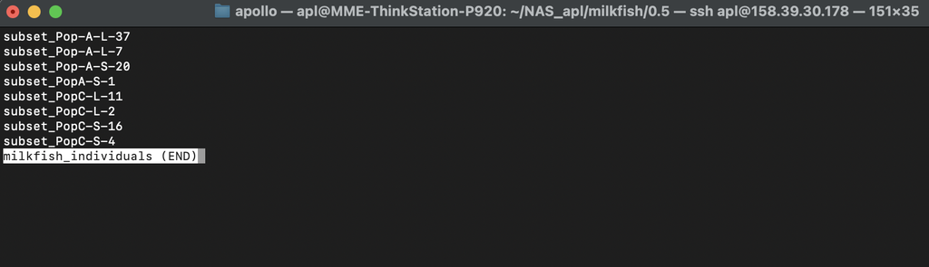

## 2. Genome Indexing - BWA mapping

### 2.1. bwa index - Index reference genome using bwa

```bash
bwa index milkfish_scaffold_ref_assembly.fasta
```

It should output several files with different file extensions (i.e., .amb, .ann, .bwt, .pac, etc.)

### 2.2. Align reads to reference file

```bash
cat milkfish_individuals | parallel --verbose -j 40 'bwa mem milkfish_scaffold_ref_assembly.fasta {}_1_trimmed.fastq.gz {}_2_trimmed.fastq.gz | \
samtools view -Sbh - -o {}_aln.bam'
```

### 2.3. Check quality of alignment / aligned reads

```bash
cat milkfish_individuals | parallel --verbose -j 40 samtools flagstat {}_aln.bam > {}_aln.txt
```

Check the output `{}_aln.txt`

Check for these:

A good samtools flagstat output typically shows:

High Mapping Rate (>90%) - Most reads are mapped.

Low Duplicate Rate (<10-20%) - Few duplicated reads.

Few Unmapped Reads - Minimal contamination or poor library quality.

High Proper Pairing (>80%) - Consistent paired-end alignments.

Low Secondary/Supplementary Alignments - Minimal ambiguous mapping.

High Primary Alignment Rate - Most reads should be primary.

Low QC-Failed Reads - Good quality control.

If not, remove the reads or subject reads to additional more stringent filtering.

## 3. Bam files clean-up

Cleaning up bam files before SNP calling is necessary as it helps with removing duplicates, sorting & indexing, realignment around indels, Base quality recalibration, filtering of low-quality reads, removing contaminants

```bash
cat milkfish_individuals | parallel --verbose -j 40 'samtools view {}_aln.bam | fgrep XA | cut -f 1 > bad_names_{}.txt samtools view -h {}_aln.bam | fgrep -vf bad_names_{}.txt | samtools view -Sb - > {}_aln2.bam samtools view {}_aln2.bam | fgrep SA | cut -f 1 > bad_names_{}.txt samtools view -h {}_aln2.bam | fgrep -vf bad_names_{}.txt | samtools view -Sb - > {}_aln3.bam samtools view -b -F 3332 -f 3 {}_aln3.bam > {}_aln3_cleaned.bam'
```

Lets break it down:

1. Input:

The code reads a list of individual names from the file milkfish_individuals using cat.

The list of individuals is piped to GNU parallel, which runs the following commands concurrently with up to 40 parallel jobs (-j 40).

2. Identify problematic reads (XA tag); XA tags indicate possible secondary alignments or chimeric reads

```bash
samtools view {}_aln.bam | fgrep XA | cut -f 1 > bad_names_{}.txt
```

3. Filter out problematic reads (XA)

```bash
samtools view -h {}_aln.bam | fgrep -vf bad_names_{}.txt | samtools view -Sb - > {}_aln2.bam
```

4. Identify problematic reads (SA tag); SA tags mean supplementary alingments

```bash
samtools view {}_aln2.bam | fgrep SA | cut -f 1 > bad_names_{}.txt
```

```bash
samtools view -b -F 3332 -f 3 {}_aln3.bam > {}_aln3_cleaned.bam
```

[output not shown]

Output: A cleaned BAM file `{}_aln3_cleaned.bam` with high-confidence, properly paired reads.

Tip: `.bam` files are huge and you can partition the commands in to portions and delete unecessary `.bam` files. Just be careful on what you delete!

## 4. Identify & Mark duplicated reads

```bash
cat milkfish_individuals | parallel --verbose -j 40 'java -jar /home/apl/NAS_apl/milkfish/0.5/picard.jar MarkDuplicates I={}_sorted.bam O={}_dedup.bam M={}_dedup_metricsfile ASSUME_SORT_ORDER=coordinate VALIDATION_STRINGENCY=SILENT REMOVE_DUPLICATES=true 2>log_{}_dedup.txt'
```

## 5. Add or Replace Group

Basically formats the file if necessary headers or key words prior to GATK is missing

```bash
cat milkfish_individuals | parallel --verbose -j 40 'java -jar /home/apl/NAS_apl/milkfish/0.5/picard.jar AddOrReplaceReadGroups I={}_dedup.bam O={}_dedup_RG.bam SORT_ORDER=coordinate RGLB=lib1 RGPL=illumina RGPU=unit54 RGSM={}
```

## 6. Index .bam files

```bash
#!/bin/bash

for file in *_RG.bam; do
samtools index $file "${file}.bai";
done
```

Q: Why do we need to index the `.bam` files before GATK?

A: Indexing BAM files before using GATK (or other similar tools) is crucial because it **enables fast and efficient access to alignment data**. Without an index, tools would have to scan the entire file to find reads mapped to specific genomic regions, which would be extremely slow, especially for large BAM files. Keyword is **Efficiency**

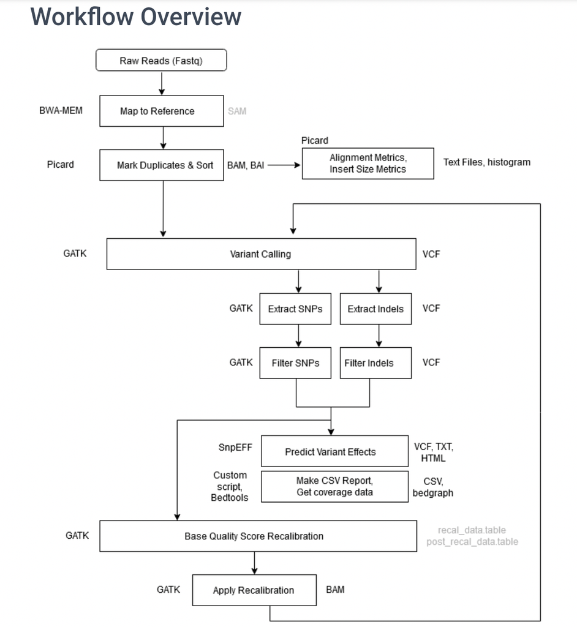

# GATK Variant Calling

## 7. Variant calling

```bash
cat milkfish_individuals | parallel --verbose -j 40 '/home/apl/NAS_apl/milkfish/0.5/gatk-4.4.0.0/gatk HaplotypeCaller \
--java-options "-Xmx500G -XX:+UseParallelGC -XX:ParallelGCThreads=40" \
-R milkfish_scaffold_ref_assembly.fasta  \
-I {}_dedup_RG.bam \
--ERC GVCF \
-O {}_variants.g.vcf'
##takes long minimum 5-6 hours / better run overnight
```

## 8. Combine GVCFs (.g.vcf)

Notes: When analyzing many samples (like a population study), it’s more efficient to combine individual GVCFs before performing joint genotyping. GVCFs store variant and non-variant information, which helps in efficient genotyping.

```bash
/home/apl/NAS_apl/milkfish/0.5/gatk-4.4.0.0/gatk CombineGVCFs \
--java-options "-Xmx100G -XX:+UseParallelGC -XX:ParallelGCThreads=20" \
-R milkfish_scaffold_ref_assembly.fasta \
--variant milkfish_vcf.list \
-O subset_milkfish_combine.g.vcf.gz 2> subset_milkfish_combine.log

##make a separate list of all variants_vcf file, rename it to file.list
##relatively fast less than 30 mins
```

Before proceeding to the next steps. You can validate the combined `.g.vcf` file to check whether everything ran smoothly or not.

## 9. ValidateGVCFs (optional)

```bash
/home/apl/NAS_apl/milkfish/0.5/gatk-4.4.0.0/gatk ValidateVariants \
    -R milkfish_scaffold_ref_assembly.fasta \
    -V subset_milkfish_combine.g.vcf.gz
```

## 10. Genotype GVCFs

Calls variants across multiple samples simultaneously, increasing the accuracy of genotypes at low-frequency variants.

```bash
/home/apl/NAS_apl/milkfish/0.5/gatk-4.4.0.0/gatk GenotypeGVCFs \
-R milkfish_scaffold_ref_assembly.fasta \
--variant subset_milkfish_combine.g.vcf.gz \
--max-alternate-alleles 18 \
-O subset_milkfish_genotype.g.vcf.gz

##relatively fast less than 1 hour
```

## 11. Select Variants

SelectVariants tool is used to filter and extract specific variants from a VCF file based on user-defined criteria. It’s a highly versatile tool that allows you to customize and subset your VCF data in various ways.Extract specific types of variants (e.g., SNPs, indels, or multi-allelic sites)

```bash
/home/apl/NAS_apl/milkfish/0.5/gatk-4.4.0.0/gatk SelectVariants \
-R milkfish_scaffold_ref_assembly.fasta \
-V subset_milkfish_genotype.g.vcf.gz \
--select-type-to-include SNP \
-O subset_milkfish_snps.vcf.gz
```

## 12. Variant Filtration

Q: Why do variant filtration?

A: Variant filtration in GATK is crucial because raw variant calls often contain **false positives** and **low-quality variants**. Filtration helps distinguish **true genetic variants** from **sequencing errors**, **artifacts**, or **low-confidence calls**.

```bash
/home/apl/NAS_apl/milkfish/0.5/gatk-4.4.0.0/gatk VariantFiltration \
-R milkfish_scaffold_ref_assembly.fasta \
-V subset_milkfish_snps.vcf.gz \
-O subset_milkfish_snps_filtered.vcf.gz 2> subset_milkfish_snps_filtered.log \
--filter-expression "QUAL < 30.0" --filter-name "LowQual" \
    --filter-expression "QD < 2.0" --filter-name "LowQD" \
    --filter-expression "FS > 60.0" --filter-name "StrandBias" \
    --filter-expression "MQ < 40.0" --filter-name "LowMQ" \
    --filter-expression "SOR > 3.0" --filter-name "HighSOR" \
```

How did we arrive with this values?

QUAL < 30: Low confidence variants.

QD < 2.0: Low quality relative to depth.

FS > 60.0: High strand bias.

MQ < 40.0: Poor mapping quality.

SOR > 3.0: Asymmetric strand bias.

### Summary of Variant filtering:

High SNP counts from a few samples may indicate technical artifacts or low-quality variant calling.

Applying stringent quality filters helps minimize false positives.

Visualize metrics using bcftools stats or vcftools.

## 13. Base Quality Recalibration (optional, but highly recommended)

```bash
gatk BaseRecalibrator \
    -R reference.fasta \
    -I input.bam \
    --known-sites dbsnp.vcf \
    --known-sites known_indels.vcf \
    -O recal_data.table
```

Apply recalibration:

```bash
gatk ApplyBQSR \
    -R reference.fasta \
    -I input.bam \
    --bqsr-recal-file recal_data.table \
    -O recalibrated.bam
```

Validate and check improvements:

```bash
gatk BaseRecalibrator \
    -R reference.fasta \
    -I recalibrated.bam \
    --known-sites dbsnp.vcf \
    --known-sites known_indels.vcf \
    -O post_recal_data.table

gatk AnalyzeCovariates \
    -before recal_data.table \
    -after post_recal_data.table \
    -plots recalibration_plots.pdf
```

## You are now ready to proceed to SNP filtering and vcf handling tutorial

## Any questions?

Other info:

**SnpEff** is a powerful tool for annotating and predicting the effects of genetic variants (like SNPs, insertions, deletions, and structural variants) on genes and proteins. It helps to understand the potential functional impact of variants identified from sequencing data